# Coursework Report

*N* removed NAs: 3

*N* removed typo: 1

*N* removed <18: 19

*N* total clean: 127

| Group | *N* | *M*<sub>age</sub> | *M*<sub>rating</sub> |
| --- | --- | --- | --- |
| Control | 61 | 21.02 | 6.85 |
| Experim | 66 | 21.68 | 6.12 |

**Main analysis results**

*t*(125) = 5.56, *p* < .001

[interactive chart not shown]

[figure not shown]

[interactive chart not shown]

# Coursework Report

Analysing Data, Spring 2020

# Methods

## Participants

Initially, we had 150 female volunteer participants, but we removed 23 because of ethical reasons as their age was either not available, or under 18, or mistakenly had letters included. This left us with 127 participants ranging from 18-27 years of age with a mean age of 21.36 and a standard deviation of 2.28.

## Design

As this study was a replication of Elliot’s et al (2010) study, the design was identical to his. We investigated whether women found men more attractive in conjunction with the colour red as opposed to no colour. Each participant viewed a monochrome 4-in X 6-in headshot of an average, young white man for 5 seconds, the photo was placed on either red background (*n* = 66) or white background (*n* = 61) which was 8.5-in X 11-in in area. The participants then answered how attractive they found the man in the form of three questions: “How attractive do you think this person is?”, “How pleasant is this person to look at?” and “If I were to meet the person in this picture face to face, I would think he is attractive.”. The participants’ answered on a 9-point scale, 1 being not at all attractive and 9 being incredibly attractive, then these scores were averaged to create a mean attractiveness score. To discover if the results are meaningful, we will be using a *t*-test to see if women’s perceptions of a man’s attractiveness are significantly affected by the colour red or white.

## Results

We investigated whether there is a relationship between the colour red and perceived attractiveness from women in men, using an independent measure *t*-test. The analysis indicated the results do not correlate with the original study (Elliot et al, 2010) as there was lower mean reported attractiveness rating in the experimental condition (*M* = 6.12) than the control group (*M* = 6.85). We calculated this composite score by adding the three scores from the attractiveness questions and dividing them by three to get the mean attractiveness score for each condition. This difference in means was significant (*M*<sub>diff</sub> = 0.74, 95% CI [0.47, 1], *t* (125) = 5.56, *p* < .001 ).Therefore, we must reject the null hypothesis and accept the alternative hypothesis as there is a found relationship between the colour red and attractiveness, but it is a negative relationship, our findings show the colour red makes men less desirable to women.

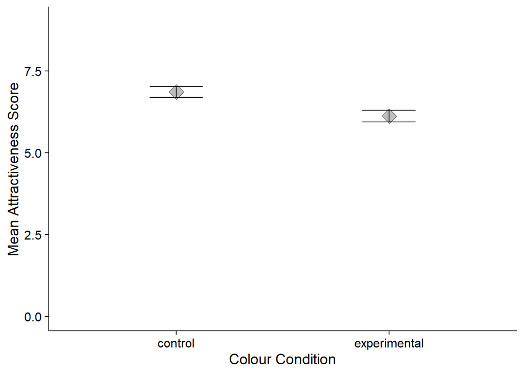

**Figure 1: Mean Attractiveness Scores in the Experimental Red Condition and the Control Condition**

# Discussion

Our findings show that the colour red decreased women’s perceived attraction to men, the control groups’ mean rated attraction scores were higher than the experimental condition’s score. We can infer from these results that red is not a factor in increasing attraction, it actually does the opposite.

In comparison to the original study, our results did not correlate with their findings, Elliot et al (2010) had a higher mean rating of attraction in the red condition (*M* = 6.79, *SD* =1.00) in comparison with the control condition (*M* = 5.67, *SD* = 1.34). Whereas, in our replication, we found the opposite result with the control condition scoring higher on attractiveness rating (*M* = 6.85) compared to the red condition (*M* = 6.12). This means that red does not conclusively increase attraction to men, and suggests that Elliot’s red effect is not consistent with everyone.

In a study investigating preferences to colour or monochrome photographs of people, it was found that participants significantly favour chromatic colours in comparison to chromatic themes (Axelsson, 2007). However, our study disputes this claim as participants preferred the photo of the man with a white background than the photograph with a colourful red background. Therefore, showing that there is no universal inclination towards the colour red, which would suggest that it is all down to personal preference and little to do with the colour. Other experiments have found that there is no relationship at all between red and attraction (Hesslinger et al, 2015; Peperkoorn et al, 2016).

A limitation of this study is that we did not account for the female participants’ romantic preferences, as the reason for lower attractiveness scores may be due to not being attracted to an average white man. This was not accounted for in the study and could have altered the results to make them biased, this could be resolved using a matched pairs design or repeated measures design. Furthermore, the sexuality of the participants was not screened for, this may have skewed the results as if some of the participants were lesbians then they would not be attracted to the image of the man regardless of what colour the background is. Additionally, these findings cannot be generalised to reality as a red border is not something that people have around them in real life, it would have been better to have the model wear a red t-shirt.

This attraction to the colour red effect is circumstantial, especially as this was an independent measures design which means all the participants in each condition do not have the same preferences in men. So, you cannot say that red causes you to be more attracted to someone than a neutral colour, multiple extraneous variables affect attraction, many of which are not accounted for.

It may be beneficial to expand on these findings with a more natural experiment to see if red effects attraction in real life, by having the models in the photograph wear a red or white t-shirt instead of having the colour in the background. This would create useful data that could be used by people who want to make them self seem more attractive.

In conclusion, this replication study did not produce the same results as the original experiment (Elliot et al, 2010) but refuted their claims and demonstrated that red actually decreases women’s perceived attraction to men.

# References

Axelsson, O. (2007). Towards a psychology of photography: Dimensions underlying aesthetic appeal of photographs. *Perceptual and Motor Skills, 105* 411–434.

Elliot, A. J., Niesta Kayser, D., Greitemeyer, T., Lichtenfeld, S., Gramzow, R. H., Maier, M. A., & Liu, H. (2010). Red, rank, and romance in women viewing men. *Journal of Experimental Psychology: General, 139*(3), 399.

Hesslinger, V.M., Goldbach, L. & Carbon, C. (2015) Men in red: A re-examination of the red-attractiveness effect. *Psychonomic Bulletin & Review 22*, 1142–1148.

Peperkoorn, L. S., Roberts, S. C., & Pollet, T. V. (2016). Revisiting the Red Effect on Attractiveness and Sexual Receptivity: No Effect of the Color Red on Human Mate Preferences. *Evolutionary Psychology*.